# AirBnb Transformation

Sebastien DIAZ

2 janvier 2016

# Introduction

Transformation of a customer appears one of the very more important act than a Startup should make to become important.

The data extracted from the AirBnb Challenge on Kaggle permits to understand a lot on the transformation time of an user. All of this user had been transformed and booking a less one time.

For All the five years the plot permits to estimate that 50% of the booking user is made on less than 6 months. 40% are transformed in less than one month.

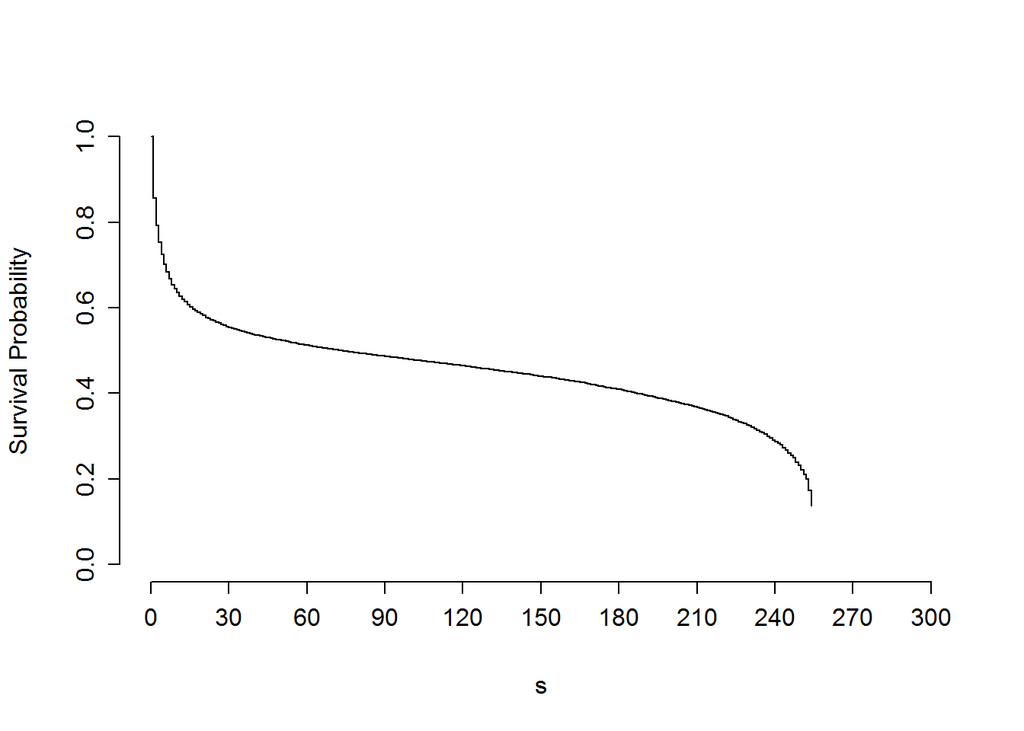

# Air Bnb on 4 years windows

In cutting the data on different window frame corresponding on the different year, we can follow the evolution of this transformation. We can see that at the beginning transforming was easy where 80% where transformed in less than two months.

This score appear identical for the 2010,2011 and 2012. I guess that apparently that during this period the transformation of the last 20% increase in time.

In 2013, a big change has appear and the transformation become more complex and just 50% have been transformed in less than 2 months.

In 2014, it is more comples where just 20% are ttrasnformed in less than 2 months.

All this plot permiits to identify that at the beginning on acquiring new client, this client were very interested on the offer of Ari Bnb. But during the time the new acquistion has certainly acquire different curomers with different feeling with the site. I can t explain the transformation because I m not inside Air bnb , but it is very interesting act.

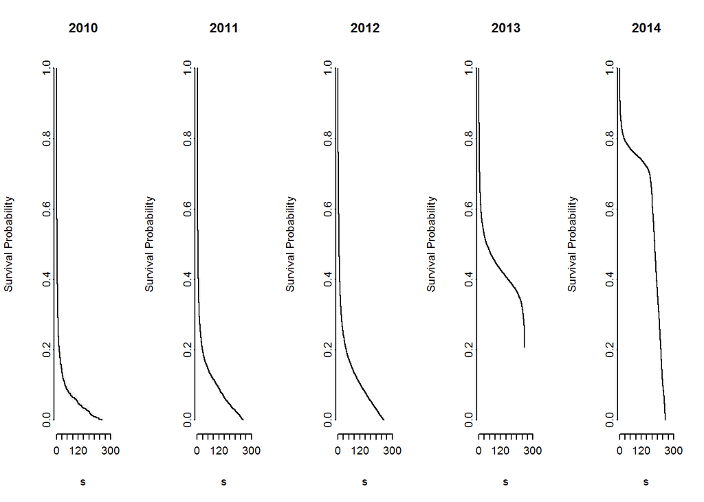

# The gender

The gender make not a real difference in term of transformation.

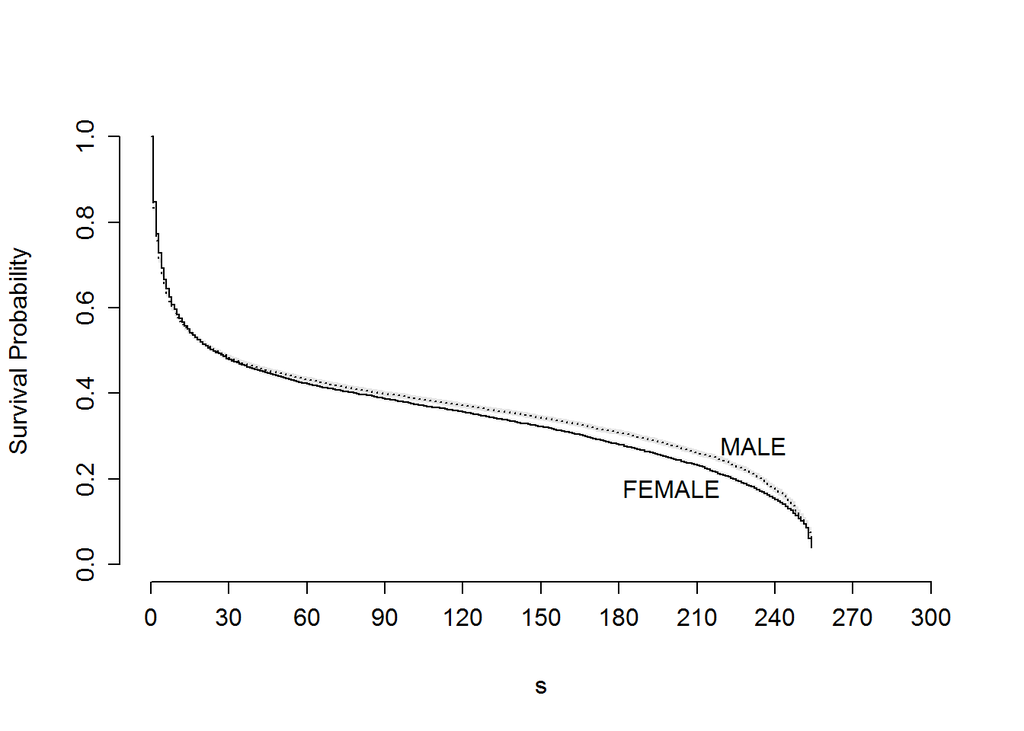

# Gender on 4 years windows

As in general we obtain a regular result obtained previously in the global view.

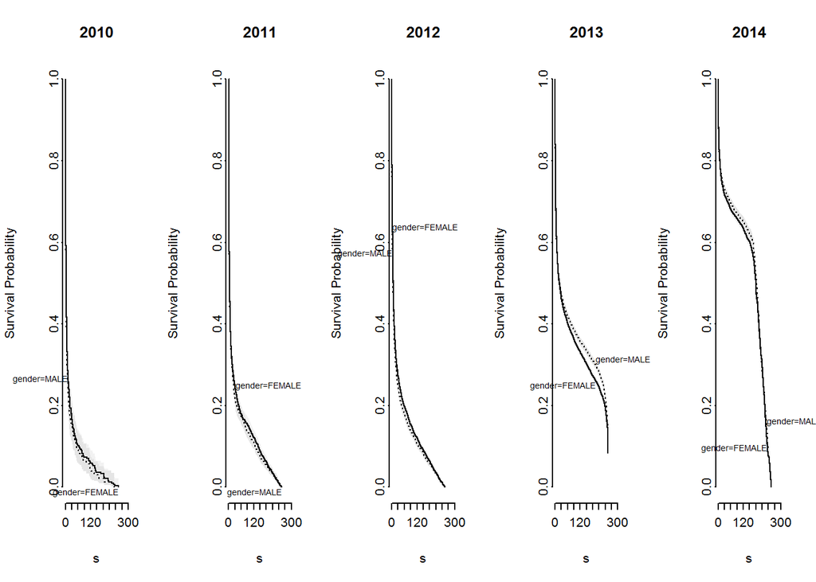

# Age

The age could become an interesting entry point to understand the personnality and the travel need of people.

As we more old we are, more we want to travel. This is certainly a period of retirement that permit to have free time to make it possible.

More young, we are more time we make to book a room. Young people are more searching a plan and search to organize at long term.

```
##
## [25,45] [45,65]     <25     >65
##   36963    8576    4504    2426
```

The more representative group are on 25-45 age old. This people are on the middle between young and old.

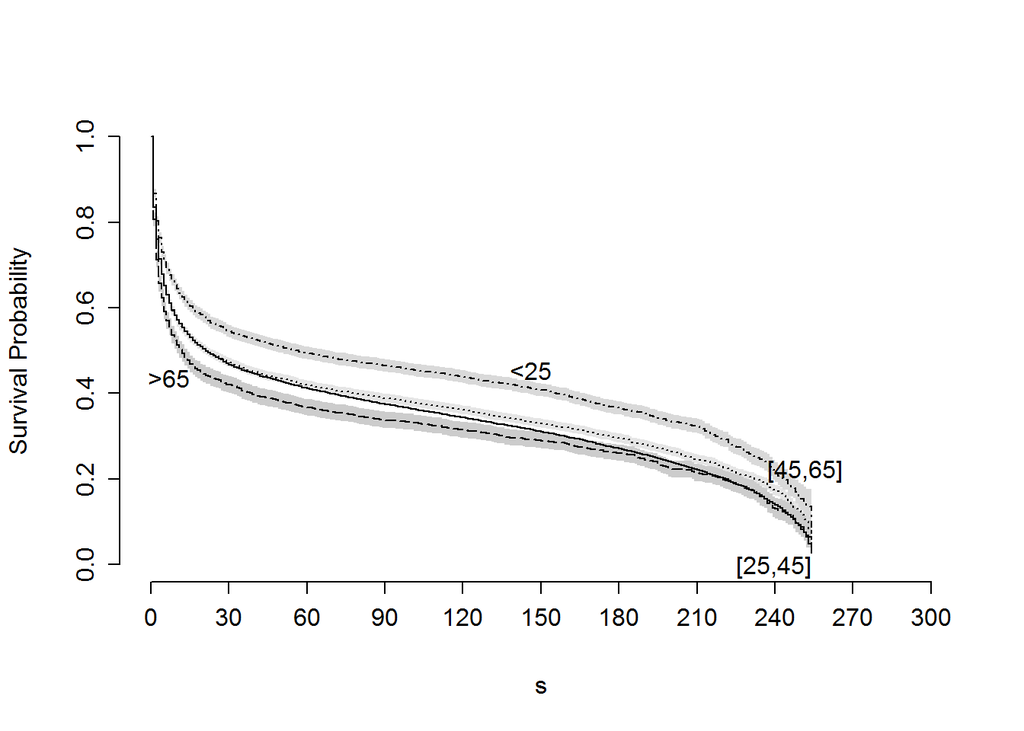

# Age on 4 years windows

Nothing change the order of the age in the booking time. Just the variability become different.

During the four three years people have relatively the same tie to book.

2013 become a trouble year, where a real difference occur between age.

2014 is reaaly different as we see previously.

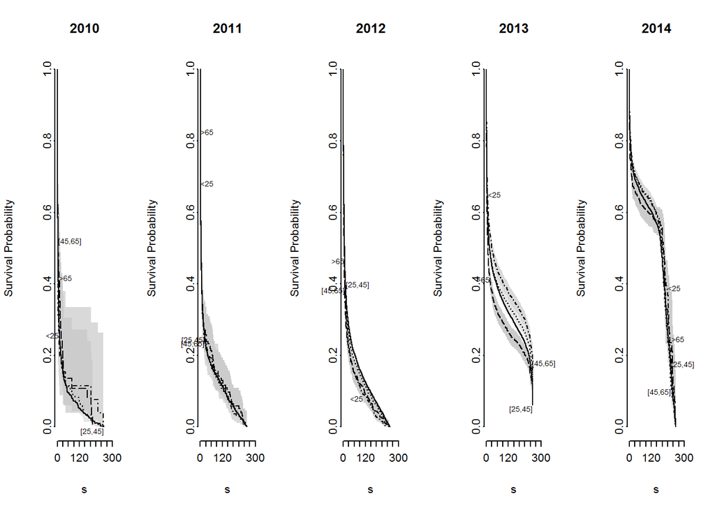

# Signup

Two signup method by facebook or internally (classic). When we see facebook users, the time become less than classical method at the end.

But people starting by classic signup are more bookers than facebook . the signup method is certainly more quick with a simple click to signup for facebook and attire users with curiosity but with less consumption desire.

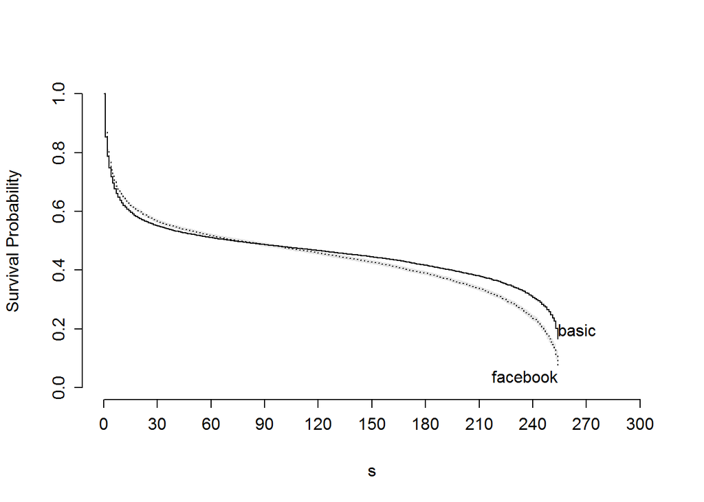

# Signup on 4 years windows

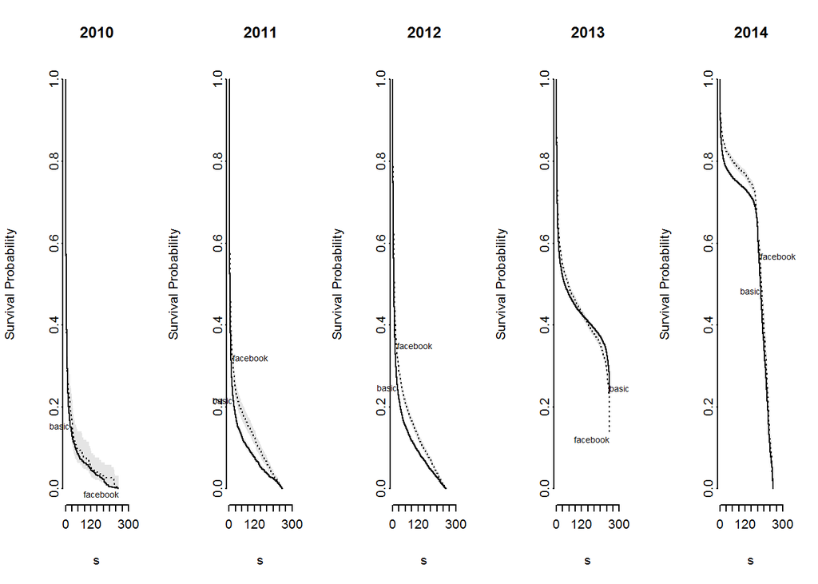

# Affliate channel

Studying the channel permits to understand which channel make the best score for booking.

The best channel is the direct or other channel.

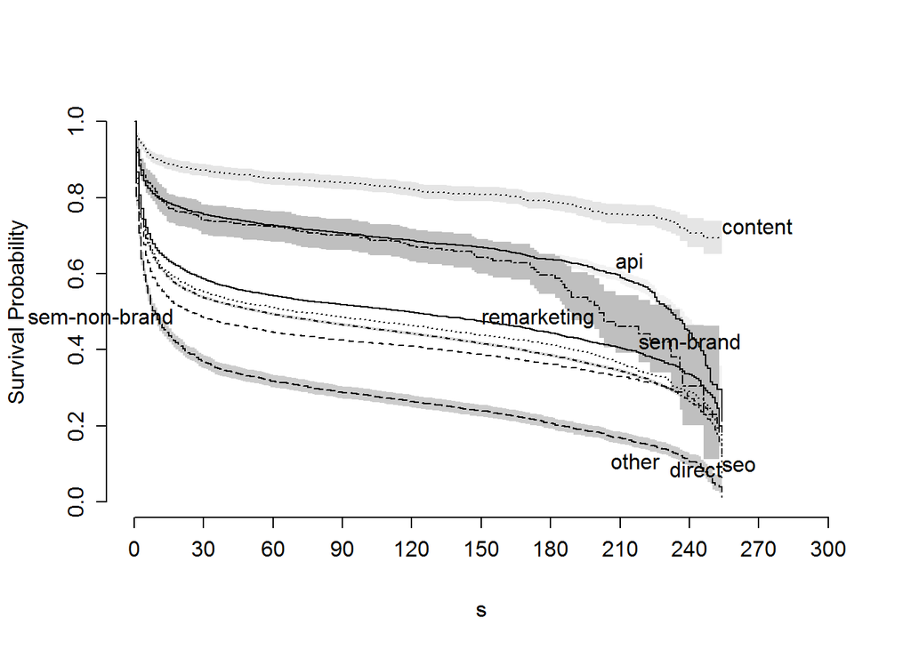

# Affliate channel on 4 years windows

During the three first year from 2010 to 2012, the booking time appear equal.

As other variable 2013 becomes different, for some reasons a real difference appears. This is the same result as for the complete dataset.

2014 has troubles.

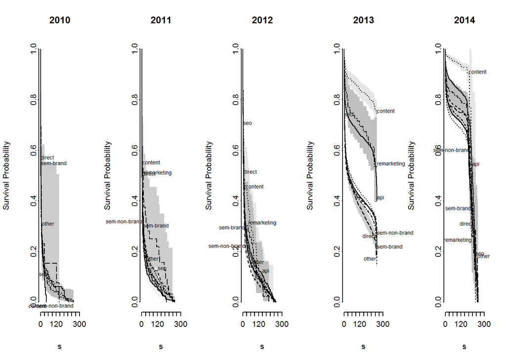

# Affliate provider on 4 years windows

If you know Air bnb Story , you will suprise that the company has make a Growth Hacking solution with Craiglist.

The best booking time comes from craiglist certainly due certainly by the previous story. It was a good idea to make this choice to retrieve customers, because craiglist is making offers on room where AirBnb has the same market segment.

The second provider is Vast. I dont know what is vast. But the result was prohiminent closely to craiglist. I can make a comparison in saying that the principal business could come from the same market.

Following bing has a good provider. Other search engine as google facebook follows bing. At final yandex was not efficient. And email marketing poorly efficient.

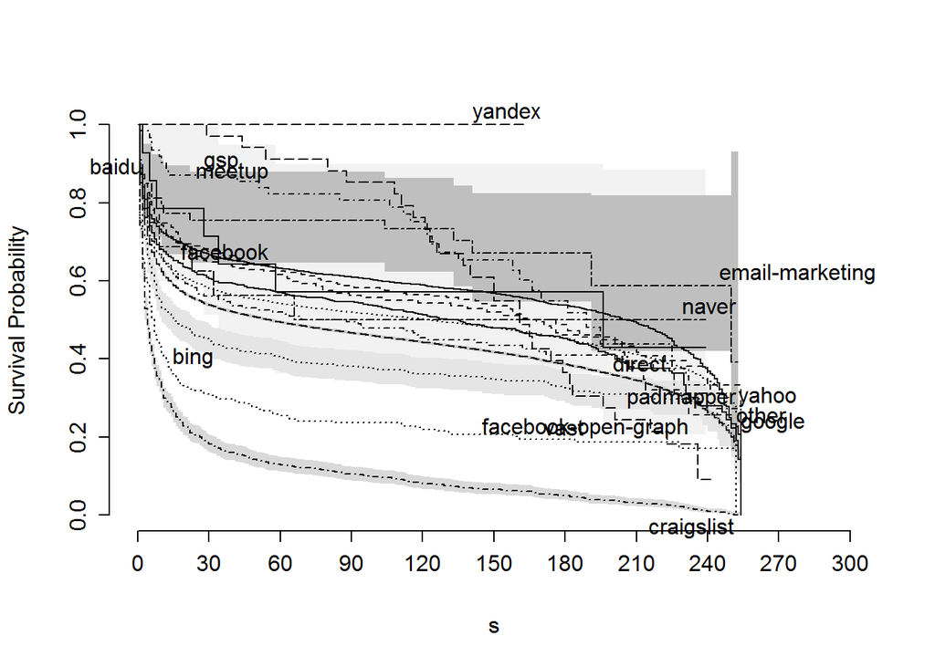

In 2010 the providers are identical.

In 2011, a difference appears on Facebook that is not efficient.

In 2012, the difference increase and we see that meetup and email marketing are not efficient. The bests are google , vast and bing. Craiglist is not the best.

In 2013, craiglist is the number one in efficiency, the search engine/faebook providers appear as one group. The email marketing is no efficient as each time we see it.

In 2014, craiglist disappear due certainly by some negative judgement from the business court . yandex appears and is certainly more bad than the email marketing.

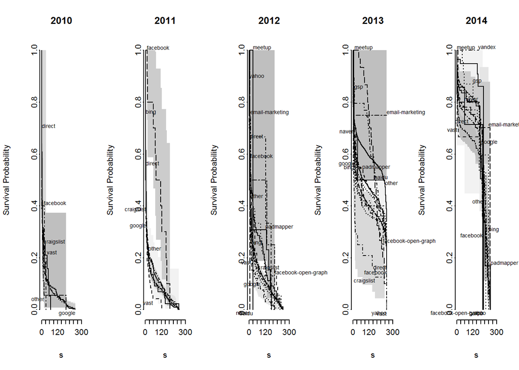

# Application Signup

Generally bookers come from the Web, the mobile arrive after all. Android at last(Logic , because android device are more cheepest than IOS. IOS users have more money to book).

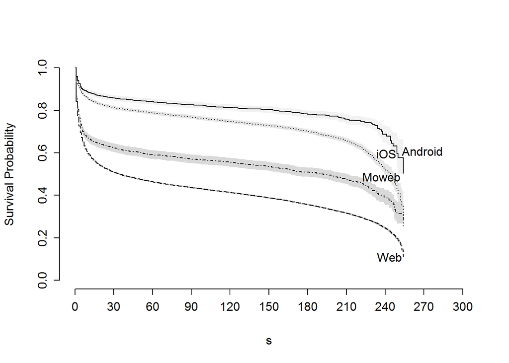

# Application Signup on 4 years windows

In 2010 and 2011, the bookers come from the Web.

In 2012, Air Bnb arrive with more application solution and a better measure of the origin. Similar in time. The web rest the best.

In 2013, the difference become more clear. The web is the more efficient. Android the less efficient.

In 2014, the web is the best as all the date we have.

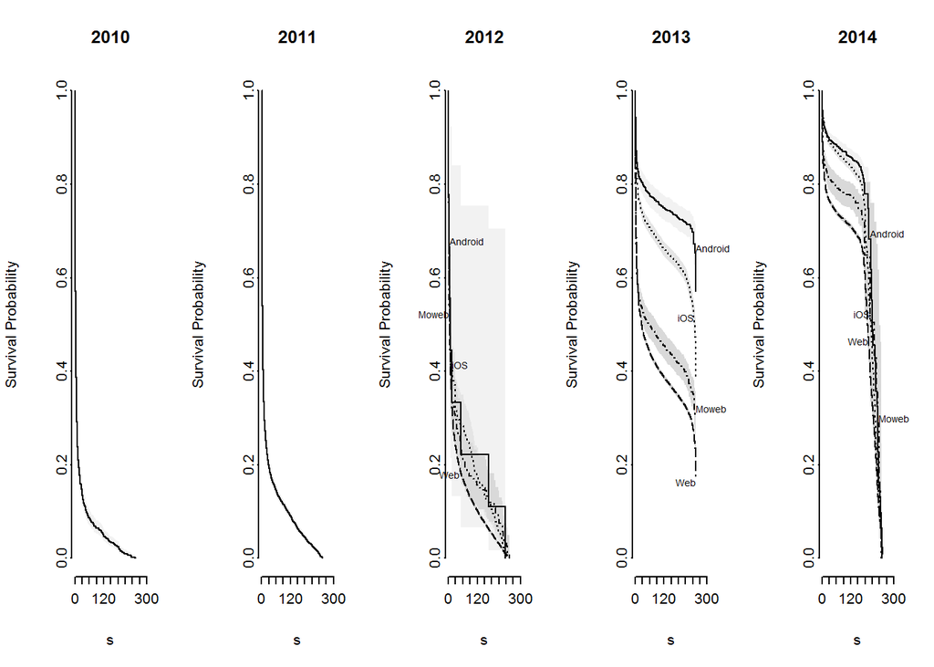